# **How did Leicester City FC Win the 2015-2016 English Premier League, and How did Arsenal FC Stack up Against Them?**

*Jarod French*  
CMSC 320 Spring 2022  
Published May 16, 2022  
Last updated May 16, 2022

while analyzing Leicester City's season.

## Introduction

The English Premier League is the top tier soccer league in England, and many believe it to be the best soccer league in the world. It is home to some of the best soccer players in the world, with names like Cristiano Ronaldo, Kevin de Bruyne, and Virgil van Dijk. The league consists of 20 teams each season, each of them playing every other team twice for a total of 38 games. The winning team is awarded 3 points, while the losing team gets no points. In the event of a tie, both teams are awarded 1 point. At the end of the season, the team with the most points is awarded the Premier League trophy for winning the league. However, the three teams that collect the least amount of points are relegated to the 2nd division of English soccer, and three teams from the second division are promoted to replace the relegated teams.  
The league is host to a number of massive clubs such as Arsenal FC, Chelsea FC, Manchester City FC, Manchester United FC, and Liverpool FC. Those 5 clubs have won the Premier League an astonishing 27 times out of 29 years. The only other two teams to win the Premier League? Blackburn Rovers in 1995 and Leicester City FC in 2016.  
Leicester City was not one of the founding 22 clubs of the Premier League in 1992, and before 2014 they had not been in the Premier League since 2004. Actually in 2008, they were in the third division of English soccer, which makes it all the more remarkable how fast they got back to the first division of English soccer in just 6 years. Now this analysis of the 2015-16 season will explain how the team that was in the third division 8 years prior, ended up winning the Premier League. It will also teach you how to do your own analysis of a team's season using python and data.

```python
%matplotlib inline
%config InlineBackend.figure_format = 'retina'
# Use the line above to make sure the plots are considered output and part of the notebook.
import pandas as pd
import numpy as np
import matplotlib.pyplot as plt
# pd is a common way of shortening the pandas name, also np for numpy, and plt for matplotlib.pyplot
```

The first step is to obtain our data from the source. For this analysis, I am using the 2015-2016 Premier League data from Sports Reference, which by their user agreement allows me to use their data if I give them credit for it.[^1] To obtain the data, you will want to:

1. Navigate to the dataset you want to use
2. Hover over the "share and export" dropdown
3. Select "get table as csv(for Excel)"
4. Copy the data and paste it into a .csv file of your choosing (most likely in your project directory)
5. Use Pandas (or another method) to read the csv file, like below

```python
# Here we read the csv file into a dataframe using the pandas read_csv function
league_table = pd.read_csv('premier_league_table.csv')
league_table
```

|  | Rk | Squad | MP | W | D | L | GF | GA | GD | Pts | Attendance | Top Team Scorer | Goalkeeper | Notes |
| --- | --- | --- | --- | --- | --- | --- | --- | --- | --- | --- | --- | --- | --- | --- |
| 0 | 1 | Leicester City | 38 | 23 | 12 | 3 | 68 | 36 | 32 | 81 | 31998 | Jamie Vardy - 24 | Kasper Schmeichel | → UEFA Champions League via league finish |
| 1 | 2 | Arsenal | 38 | 20 | 11 | 7 | 65 | 36 | 29 | 71 | 59944 | Olivier Giroud - 16 | Petr Čech | → UEFA Champions League via league finish |
| 2 | 3 | Tottenham | 38 | 19 | 13 | 6 | 69 | 35 | 34 | 70 | 35776 | Harry Kane - 25 | Hugo Lloris | → UEFA Champions League via league finish |
| 3 | 4 | Manchester City | 38 | 19 | 9 | 10 | 71 | 41 | 30 | 66 | 54041 | Sergio Agüero - 24 | Joe Hart | → UEFA Champions League via league finish |
| 4 | 5 | Manchester Utd | 38 | 19 | 9 | 10 | 49 | 35 | 14 | 66 | 75286 | Anthony Martial - 11 | David de Gea | → UEFA Europa League via cup win 1 |
| 5 | 6 | Southampton | 38 | 18 | 9 | 11 | 59 | 41 | 18 | 63 | 30751 | Graziano Pellè Sadio Mané - 11 | Fraser Forster | → UEFA Europa League via league finish 2 |
| 6 | 7 | West Ham | 38 | 16 | 14 | 8 | 65 | 51 | 14 | 62 | 34910 | Dimitri Payet Andy Carroll - 9 | Adrián | → UEFA Europa League via league finish 3 |
| 7 | 8 | Liverpool | 38 | 16 | 12 | 10 | 63 | 50 | 13 | 60 | 43910 | Roberto Firmino - 10 | Simon Mignolet | NaN |
| 8 | 9 | Stoke City | 38 | 14 | 9 | 15 | 41 | 55 | -14 | 51 | 27534 | Marko Arnautović - 11 | Jack Butland | NaN |
| 9 | 10 | Chelsea | 38 | 12 | 14 | 12 | 59 | 53 | 6 | 50 | 41500 | Diego Costa - 12 | Thibaut Courtois | NaN |
| 10 | 11 | Everton | 38 | 11 | 14 | 13 | 59 | 55 | 4 | 47 | 38124 | Romelu Lukaku - 18 | Tim Howard | NaN |
| 11 | 12 | Swansea City | 38 | 12 | 11 | 15 | 42 | 52 | -10 | 47 | 20711 | André Ayew - 12 | Łukasz Fabiański | NaN |
| 12 | 13 | Watford | 38 | 12 | 9 | 17 | 40 | 50 | -10 | 45 | 20594 | Odion Ighalo - 15 | Heurelho Gomes | NaN |
| 13 | 14 | West Brom | 38 | 10 | 13 | 15 | 34 | 48 | -14 | 43 | 24631 | Salomón Rondón - 9 | Boaz Myhill | NaN |
| 14 | 15 | Crystal Palace | 38 | 11 | 9 | 18 | 39 | 51 | -12 | 42 | 24825 | Connor Wickham Scott Dann... - 5 | Wayne Hennessey | NaN |
| 15 | 16 | Bournemouth | 38 | 11 | 9 | 18 | 45 | 67 | -22 | 42 | 11189 | Joshua King - 6 | Artur Boruc | NaN |
| 16 | 17 | Sunderland | 38 | 9 | 12 | 17 | 48 | 62 | -14 | 39 | 43071 | Jermain Defoe - 15 | Vito Mannone | NaN |
| 17 | 18 | Newcastle Utd | 38 | 9 | 10 | 19 | 44 | 65 | -21 | 37 | 49754 | Georginio Wijnaldum - 11 | Rob Elliot | Relegated |
| 18 | 19 | Norwich City | 38 | 9 | 7 | 22 | 39 | 67 | -28 | 34 | 26972 | Dieumerci Mbokani - 7 | John Ruddy | Relegated |
| 19 | 20 | Aston Villa | 38 | 3 | 8 | 27 | 27 | 76 | -49 | 17 | 33690 | Jordan Ayew - 7 | Brad Guzan | Relegated |

This league table shows the placings of each team after the season concluded in May 2016. Each team has played 38 league games (MP column = matches played) and Leicester City has come out on top with 81 points (Pts column) and a record of 23-12-3 (W-D-L).  
We can go ahead and get rid of the Notes, Top Team Scorer, and Goalkeeper columns becasue they don't add anything to this table that will not be in one of the other tables we will use later. Obviously if your data is different, you might want to keep those columns.

```python
league_table = league_table.drop(['Notes','Goalkeeper','Top Team Scorer'], axis=1)
league_table
```

|  | Rk | Squad | MP | W | D | L | GF | GA | GD | Pts | Attendance |
| --- | --- | --- | --- | --- | --- | --- | --- | --- | --- | --- | --- |
| 0 | 1 | Leicester City | 38 | 23 | 12 | 3 | 68 | 36 | 32 | 81 | 31998 |
| 1 | 2 | Arsenal | 38 | 20 | 11 | 7 | 65 | 36 | 29 | 71 | 59944 |
| 2 | 3 | Tottenham | 38 | 19 | 13 | 6 | 69 | 35 | 34 | 70 | 35776 |
| 3 | 4 | Manchester City | 38 | 19 | 9 | 10 | 71 | 41 | 30 | 66 | 54041 |
| 4 | 5 | Manchester Utd | 38 | 19 | 9 | 10 | 49 | 35 | 14 | 66 | 75286 |
| 5 | 6 | Southampton | 38 | 18 | 9 | 11 | 59 | 41 | 18 | 63 | 30751 |
| 6 | 7 | West Ham | 38 | 16 | 14 | 8 | 65 | 51 | 14 | 62 | 34910 |
| 7 | 8 | Liverpool | 38 | 16 | 12 | 10 | 63 | 50 | 13 | 60 | 43910 |
| 8 | 9 | Stoke City | 38 | 14 | 9 | 15 | 41 | 55 | -14 | 51 | 27534 |
| 9 | 10 | Chelsea | 38 | 12 | 14 | 12 | 59 | 53 | 6 | 50 | 41500 |
| 10 | 11 | Everton | 38 | 11 | 14 | 13 | 59 | 55 | 4 | 47 | 38124 |
| 11 | 12 | Swansea City | 38 | 12 | 11 | 15 | 42 | 52 | -10 | 47 | 20711 |
| 12 | 13 | Watford | 38 | 12 | 9 | 17 | 40 | 50 | -10 | 45 | 20594 |
| 13 | 14 | West Brom | 38 | 10 | 13 | 15 | 34 | 48 | -14 | 43 | 24631 |
| 14 | 15 | Crystal Palace | 38 | 11 | 9 | 18 | 39 | 51 | -12 | 42 | 24825 |
| 15 | 16 | Bournemouth | 38 | 11 | 9 | 18 | 45 | 67 | -22 | 42 | 11189 |
| 16 | 17 | Sunderland | 38 | 9 | 12 | 17 | 48 | 62 | -14 | 39 | 43071 |
| 17 | 18 | Newcastle Utd | 38 | 9 | 10 | 19 | 44 | 65 | -21 | 37 | 49754 |
| 18 | 19 | Norwich City | 38 | 9 | 7 | 22 | 39 | 67 | -28 | 34 | 26972 |
| 19 | 20 | Aston Villa | 38 | 3 | 8 | 27 | 27 | 76 | -49 | 17 | 33690 |

Obviously Leicester City won the Premier League by having the most points as the league table indicates, but there are other stats that tell us why they had the most points. We are going to want to plot a several statistics, so lets go ahead and write a function that will display a plot for us to simplify each step.

```python
def simple_plot(xdata, ydata, xmax, ymax, xmin, ymin, xticks, yticks, title, xlabel, ylabel):
    plt.figure(figsize=(12,8)) # make the plot larger
    # These lines center the plot on the data.
    plt.xlim(xmin=xmin,xmax=xmax + xticks)
    plt.xticks(range(xmin, xmax + xticks, xticks))
    plt.ylim(ymin=ymin, ymax=ymax + yticks)
    plt.yticks(range(ymin, ymax + yticks, yticks))
    # plot the data
    plt.scatter(xdata, ydata)
    # labels for the axes
    plt.title(title, fontsize=20)
    plt.xlabel(xlabel)
    plt.ylabel(ylabel)
    plt.show()
```

To start let's take a look at their offensive record, the Goals For (GF) column. We will plot the Rank column as the x data and the goals for will be the y data.

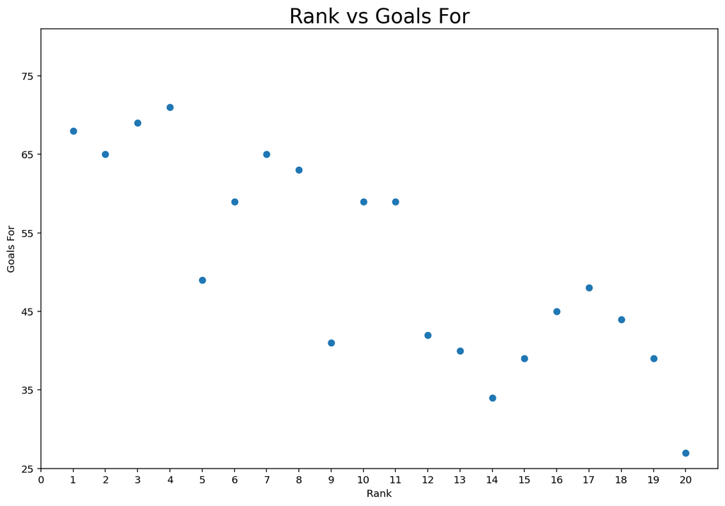

```python
simple_plot(xdata=league_table['Rk'], ydata=league_table['GF'], xmax=league_table['Rk'].max(),
            ymax=league_table['GF'].max(), xmin=league_table['Rk'].min() - 1, ymin=league_table['GF'].min() - 2,
            xticks=1, yticks=10, title="Rank vs Goals For", xlabel="Rank", ylabel="Goals For")
```

As we can see, Leicester City was one of the top goalscoring teams, but the most important part of this plot is the trend that shows that the teams that score more goals tend to rank higher at the end of the season. Now lets look at their defense. We will plot Rank vs Goals Against.

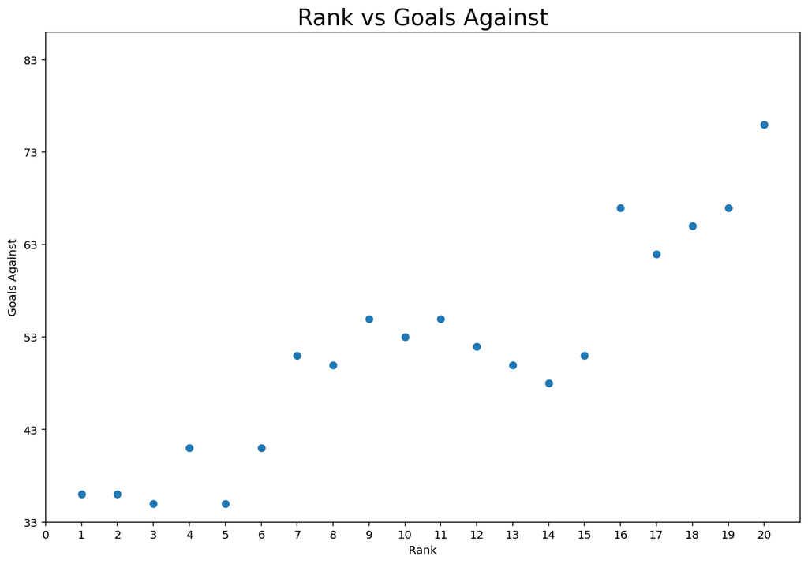

```python
simple_plot(xdata=league_table['Rk'], ydata=league_table['GA'], xmax=league_table['Rk'].max(),
            ymax=league_table['GA'].max(), xmin=league_table['Rk'].min() - 1, ymin=league_table['GA'].min() - 2,
            xticks=1, yticks=10, title="Rank vs Goals Against", xlabel="Rank", ylabel="Goals Against")
```

As we can see, Leicester City has one of the best defensize records in the Premier League in 2015-2016, and as the plot suggests, better teams conced less goals. This combined with their high scoring offense was crucial to winning the title. Now lets look at their goals against vs goals for. We will not be able to use our function because we need to label the points.

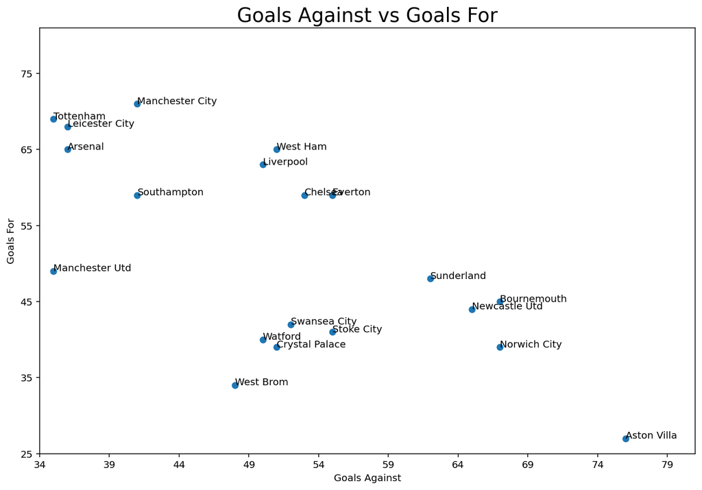

```python
plt.figure(figsize=(12,8)) # make the plot larger
# These lines center the plot on the data.
plt.xlim(xmin=league_table['GA'].min() - 1,xmax=league_table['GA'].max() + 5)
plt.xticks(range(league_table['GA'].min() - 1, league_table['GA'].max() + 5, 5))
plt.ylim(ymin=league_table['GF'].min() - 2, ymax=league_table['GF'].max() + 10)
plt.yticks(range(league_table['GF'].min() - 2, league_table['GF'].max() + 10, 10))
# plot the data
plt.scatter(league_table['GA'], league_table['GF'])
# labels for the axes
plt.title("Goals Against vs Goals For", fontsize=20)
plt.xlabel("Goals Against")
plt.ylabel("Goals For")

for i in range(0,league_table['Squad'].size):
    plt.annotate(league_table['Squad'][i], (league_table['GA'][i],league_table['GF'][i]))
```

Again we see that the best teams score a lot and concede fewer goals than other teams. Leicester City is in the top left part of the plot which is exactly where teams want to be. These plots were the very simple and obvious reasons that Leicester City won the Premier League.  
Now we will dive into some less obvious reasons. To start, we have a little bit more data that we can add to our league table, in the form of the misc stats csv. There is data that shows up as NaN, which is not recorded and since it is the entire column, we can exclude it.

```python
# Clean misc stats
misc_stats = pd.read_csv('prem_misc_stats.csv')
misc_stats
```

|  | Squad | # Pl | 90s | CrdY | CrdR | 2CrdY | Fls | Fld | Off | Crs | Int | TklW | PKwon | PKcon | OG |
| --- | --- | --- | --- | --- | --- | --- | --- | --- | --- | --- | --- | --- | --- | --- | --- |
| 0 | Arsenal | 25 | 38.0 | 0 | 0 | NaN | 348 | NaN | NaN | NaN | NaN | NaN | NaN | NaN | NaN |
| 1 | Aston Villa | 29 | 38.0 | 0 | 0 | NaN | 429 | NaN | NaN | NaN | NaN | NaN | NaN | NaN | NaN |
| 2 | Bournemouth | 28 | 38.0 | 0 | 0 | NaN | 361 | NaN | NaN | NaN | NaN | NaN | NaN | NaN | NaN |
| 3 | Chelsea | 28 | 38.0 | 0 | 0 | NaN | 401 | NaN | NaN | NaN | NaN | NaN | NaN | NaN | NaN |
| 4 | Crystal Palace | 30 | 38.0 | 0 | 0 | NaN | 465 | NaN | NaN | NaN | NaN | NaN | NaN | NaN | NaN |
| 5 | Everton | 31 | 38.0 | 0 | 0 | NaN | 306 | NaN | NaN | NaN | NaN | NaN | NaN | NaN | NaN |
| 6 | Leicester City | 23 | 38.0 | 0 | 0 | NaN | 406 | NaN | NaN | NaN | NaN | NaN | NaN | NaN | NaN |
| 7 | Liverpool | 34 | 38.0 | 0 | 0 | NaN | 410 | NaN | NaN | NaN | NaN | NaN | NaN | NaN | NaN |
| 8 | Manchester City | 25 | 38.0 | 0 | 0 | NaN | 409 | NaN | NaN | NaN | NaN | NaN | NaN | NaN | NaN |
| 9 | Manchester Utd | 33 | 38.0 | 0 | 0 | NaN | 473 | NaN | NaN | NaN | NaN | NaN | NaN | NaN | NaN |
| 10 | Newcastle Utd | 31 | 38.0 | 0 | 0 | NaN | 419 | NaN | NaN | NaN | NaN | NaN | NaN | NaN | NaN |
| 11 | Norwich City | 28 | 38.0 | 0 | 0 | NaN | 431 | NaN | NaN | NaN | NaN | NaN | NaN | NaN | NaN |
| 12 | Southampton | 26 | 38.0 | 0 | 0 | NaN | 417 | NaN | NaN | NaN | NaN | NaN | NaN | NaN | NaN |
| 13 | Stoke City | 27 | 38.0 | 0 | 0 | NaN | 420 | NaN | NaN | NaN | NaN | NaN | NaN | NaN | NaN |
| 14 | Sunderland | 31 | 38.0 | 0 | 0 | NaN | 484 | NaN | NaN | NaN | NaN | NaN | NaN | NaN | NaN |
| 15 | Swansea City | 27 | 38.0 | 0 | 0 | NaN | 392 | NaN | NaN | NaN | NaN | NaN | NaN | NaN | NaN |
| 16 | Tottenham | 24 | 38.0 | 0 | 0 | NaN | 451 | NaN | NaN | NaN | NaN | NaN | NaN | NaN | NaN |
| 17 | Watford | 25 | 38.0 | 0 | 0 | NaN | 455 | NaN | NaN | NaN | NaN | NaN | NaN | NaN | NaN |
| 18 | West Brom | 28 | 38.0 | 0 | 0 | NaN | 400 | NaN | NaN | NaN | NaN | NaN | NaN | NaN | NaN |
| 19 | West Ham | 28 | 38.0 | 0 | 0 | NaN | 381 | NaN | NaN | NaN | NaN | NaN | NaN | NaN | NaN |

```python
# We don't need these missing columns
misc_stats = misc_stats.drop(['90s','CrdY','CrdR','2CrdY','Fld','Off','Crs','Int','TklW','PKwon','PKcon','OG'], axis=1)
misc_stats.head()
```

|  | Squad | # Pl | Fls |
| --- | --- | --- | --- |
| 0 | Arsenal | 25 | 348 |
| 1 | Aston Villa | 29 | 429 |
| 2 | Bournemouth | 28 | 361 |
| 3 | Chelsea | 28 | 401 |
| 4 | Crystal Palace | 30 | 465 |

Now that we have the Fouls and number of players played columns, we can go ahead and merge the misc stats with our league table. We will use an inner join because both tables have a 'Squad' Column.

```python
league_table = league_table.merge(misc_stats, how='inner', on='Squad')
league_table
```

|  | Rk | Squad | MP | W | D | L | GF | GA | GD | Pts | Attendance | # Pl | Fls |
| --- | --- | --- | --- | --- | --- | --- | --- | --- | --- | --- | --- | --- | --- |
| 0 | 1 | Leicester City | 38 | 23 | 12 | 3 | 68 | 36 | 32 | 81 | 31998 | 23 | 406 |
| 1 | 2 | Arsenal | 38 | 20 | 11 | 7 | 65 | 36 | 29 | 71 | 59944 | 25 | 348 |
| 2 | 3 | Tottenham | 38 | 19 | 13 | 6 | 69 | 35 | 34 | 70 | 35776 | 24 | 451 |
| 3 | 4 | Manchester City | 38 | 19 | 9 | 10 | 71 | 41 | 30 | 66 | 54041 | 25 | 409 |
| 4 | 5 | Manchester Utd | 38 | 19 | 9 | 10 | 49 | 35 | 14 | 66 | 75286 | 33 | 473 |
| 5 | 6 | Southampton | 38 | 18 | 9 | 11 | 59 | 41 | 18 | 63 | 30751 | 26 | 417 |
| 6 | 7 | West Ham | 38 | 16 | 14 | 8 | 65 | 51 | 14 | 62 | 34910 | 28 | 381 |
| 7 | 8 | Liverpool | 38 | 16 | 12 | 10 | 63 | 50 | 13 | 60 | 43910 | 34 | 410 |
| 8 | 9 | Stoke City | 38 | 14 | 9 | 15 | 41 | 55 | -14 | 51 | 27534 | 27 | 420 |
| 9 | 10 | Chelsea | 38 | 12 | 14 | 12 | 59 | 53 | 6 | 50 | 41500 | 28 | 401 |
| 10 | 11 | Everton | 38 | 11 | 14 | 13 | 59 | 55 | 4 | 47 | 38124 | 31 | 306 |
| 11 | 12 | Swansea City | 38 | 12 | 11 | 15 | 42 | 52 | -10 | 47 | 20711 | 27 | 392 |
| 12 | 13 | Watford | 38 | 12 | 9 | 17 | 40 | 50 | -10 | 45 | 20594 | 25 | 455 |
| 13 | 14 | West Brom | 38 | 10 | 13 | 15 | 34 | 48 | -14 | 43 | 24631 | 28 | 400 |
| 14 | 15 | Crystal Palace | 38 | 11 | 9 | 18 | 39 | 51 | -12 | 42 | 24825 | 30 | 465 |
| 15 | 16 | Bournemouth | 38 | 11 | 9 | 18 | 45 | 67 | -22 | 42 | 11189 | 28 | 361 |
| 16 | 17 | Sunderland | 38 | 9 | 12 | 17 | 48 | 62 | -14 | 39 | 43071 | 31 | 484 |
| 17 | 18 | Newcastle Utd | 38 | 9 | 10 | 19 | 44 | 65 | -21 | 37 | 49754 | 31 | 419 |
| 18 | 19 | Norwich City | 38 | 9 | 7 | 22 | 39 | 67 | -28 | 34 | 26972 | 28 | 431 |
| 19 | 20 | Aston Villa | 38 | 3 | 8 | 27 | 27 | 76 | -49 | 17 | 33690 | 29 | 429 |

Now we will plot a bar plot of The fouls each team has committed, to find out if discipline is important to winning or not.

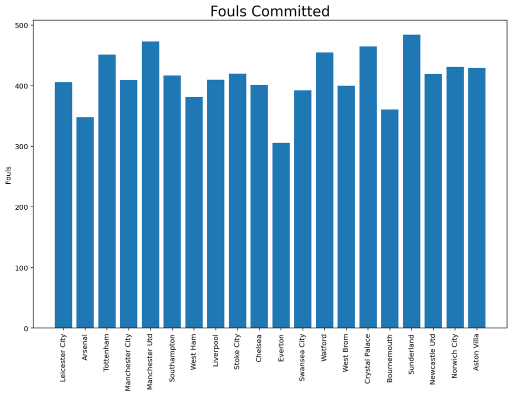

```python
plt.figure(figsize=(12,8)) # make the plot larger
# These lines center the plot on the data.
# plt.ylim(ymin=league_table['Fls'].min() - 2, ymax=league_table['GF'].max() + 10)
# plt.yticks(range(league_table['GF'].min() - 2, league_table['GF'].max() + 10, 10))
# plot the data
plt.bar(league_table['Squad'], league_table['Fls'])
plt.xticks(rotation=90)
# labels for the axes
plt.title("Fouls Committed", fontsize=20)
# plt.xlabel("Goals Against")
plt.ylabel("Fouls")

# for i in range(0,league_table['Squad'].size):
#     plt.annotate(league_table['Squad'][i], (league_table['GA'][i],league_table['GF'][i]))
```

From what we can see, there is no clear trend relating the amount of fouls each team commits over the course of a season to the final positions of each team. Although we do see Leicester City did not commit the most fouls in the league or the least fouls in the league.

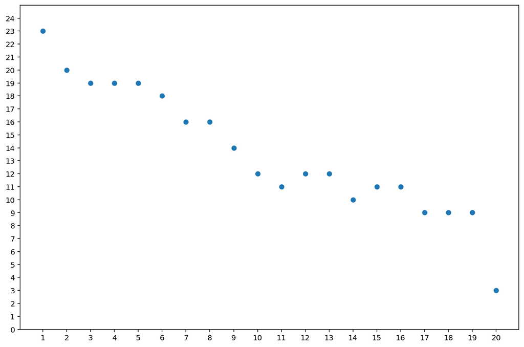

```python
plt.figure(figsize=(12,8))
# plt.xlim(xmin=0,xmax=22)
plt.xticks(range(0,22,1) )
plt.ylim(ymin=0, ymax=25)
plt.yticks(range(0,25,1) )
plt.plot(league_table['Rk'], league_table['W'], 'o')
```

As expected, the number of wins goes down the further down the table you get from 1st place to 20th place. However, since draws are worth points also, we should add them to this graph, although in this case, we would just be graphing rank vs points.

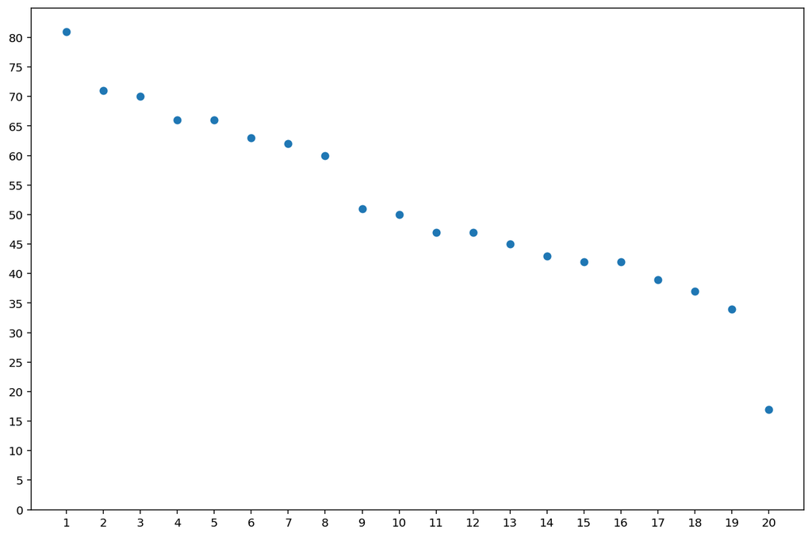

```python
plt.figure(figsize=(12,8))
# plt.xlim(xmin=0,xmax=22)
plt.xticks(range(0,22,1) )
plt.ylim(ymin=0, ymax=85)
plt.yticks(range(0,85,5) )
plt.plot(league_table['Rk'], league_table['Pts'], 'o')
```

```python
# Here we read the csv file into a dataframe using the pandas read_csv function
player_stats = pd.read_csv('prem_player_stats.csv')
player_stats
```

|  | Rk | Player | Nation | Pos | Squad | Age | Born | MP | Starts | Min | ... | PK | PKatt | CrdY | CrdR | Gls.1 | Ast.1 | G+A | G-PK.1 | G+A-PK | Matches |
| --- | --- | --- | --- | --- | --- | --- | --- | --- | --- | --- | --- | --- | --- | --- | --- | --- | --- | --- | --- | --- | --- |
| 0 | 1 | Patrick van Aanholt\5f09991f | nl NED | DF | Sunderland | 24 | 1990 | 33 | 33 | 2970 | ... | 0 | 0 | 2 | 0 | 0.12 | 0.09 | 0.21 | 0.12 | 0.21 | Matches |
| 1 | 2 | Rolando Aarons\c5942695 | eng ENG | DFMF | Newcastle Utd | 19 | 1995 | 10 | 3 | 381 | ... | 0 | 0 | 1 | 0 | 0.24 | 0.24 | 0.47 | 0.24 | 0.47 | Matches |
| 2 | 3 | Almen Abdi\8d425d84 | ch SUI | MF | Watford | 28 | 1986 | 32 | 25 | 1974 | ... | 0 | 0 | 4 | 0 | 0.09 | 0.00 | 0.09 | 0.09 | 0.09 | Matches |
| 3 | 4 | Tammy Abraham\f586779e | eng ENG | FW | Chelsea | 17 | 1997 | 2 | 0 | 55 | ... | 0 | 0 | 0 | 0 | 0.00 | 0.00 | 0.00 | 0.00 | 0.00 | Matches |
| 4 | 5 | Charlie Adam\aff418dc | sct SCO | MF | Stoke City | 29 | 1985 | 22 | 12 | 1044 | ... | 0 | 0 | 6 | 1 | 0.09 | 0.09 | 0.17 | 0.09 | 0.17 | Matches |
| ... | ... | ... | ... | ... | ... | ... | ... | ... | ... | ... | ... | ... | ... | ... | ... | ... | ... | ... | ... | ... | ... |
| 556 | 557 | Ashley Young\be927d03 | eng ENG | DFMF | Manchester Utd | 30 | 1985 | 18 | 11 | 1065 | ... | 0 | 0 | 5 | 0 | 0.08 | 0.17 | 0.25 | 0.08 | 0.25 | Matches |
| 557 | 558 | Pablo Zabaleta\6813ac34 | ar ARG | DF | Manchester City | 30 | 1985 | 13 | 12 | 1062 | ... | 0 | 0 | 3 | 0 | 0.00 | 0.08 | 0.08 | 0.00 | 0.08 | Matches |
| 558 | 559 | Wilfried Zaha\b2bc3b1f | ci CIV | MFFW | Crystal Palace | 22 | 1992 | 34 | 30 | 2488 | ... | 0 | 0 | 5 | 0 | 0.07 | 0.04 | 0.11 | 0.07 | 0.11 | Matches |
| 559 | 560 | Mauro Zárate\cc18ff4c | ar ARG | MFFW | West Ham | 28 | 1987 | 15 | 9 | 788 | ... | 0 | 0 | 1 | 0 | 0.34 | 0.00 | 0.34 | 0.34 | 0.34 | Matches |
| 560 | 561 | Kurt Zouma\ce4246f5 | fr FRA | DF | Chelsea | 20 | 1994 | 23 | 21 | 1918 | ... | 0 | 0 | 0 | 0 | 0.05 | 0.05 | 0.09 | 0.05 | 0.09 | Matches |

561 rows × 24 columns

As you can see, some of the data is not in the format we would like, such as the names of the players and their nationalities. Now we can see the data in a nice format, but some is different than what we want so we have to clean the data.  
We don't need the matches column, since we have season stats. we need to extract the players names and nationalities from the way that pandas read the data, and we need to separate the positions for those players that have more than 1 position. (add 2nd column for 2nd position). Also rename the columns that are duplicate names, for what they actually represent.

```python
# clean player table: NaNs where the column doesn't apply, 0s where the player recorded 0 or if that column doesn't apply.

player_stats = player_stats.drop('Matches', axis=1)
player_stats['Player'] = player_stats['Player'].str.extract(r'(.*?)\\.*')
player_stats['Nation'] = player_stats['Nation'].str.extract(r'([A-Z]+)')
list = player_stats['Pos'].str.extract(r'([A-Z]{2})([A-Z]{2})?')
player_stats['Pos'] = list[0]
player_stats['2nd_Pos'] = list[1]
# player_stats['Pos'] = player_stats['Pos'].str.extract(r'([A-Z]{2})')
player_stats = player_stats[['Rk', 'Player', 'Nation', 'Pos','2nd_Pos', 'Squad', 'Age', 'Born', 'MP', 'Starts','Min', '90s',
                            'Gls', 'Ast', 'G-PK', 'PK', 'PKatt', 'CrdY', 'CrdR', 'Gls.1', 'Ast.1', 'G+A', 'G-PK.1', 'G+A-PK']]
player_stats['Gls_per_90'] = player_stats['Gls.1']
player_stats['Ast_per_90'] = player_stats['Ast.1']
player_stats['G+A_per_90'] = player_stats['G+A']
player_stats['G-PK_per_90'] = player_stats['G-PK.1']
player_stats['G+A-PK_per_90'] = player_stats['G+A-PK']
player_stats = player_stats.drop(['Rk', 'Gls.1', 'Ast.1', 'G+A', 'G-PK.1', 'G+A-PK'], axis=1)
player_stats.head()
```

|  | Player | Nation | Pos | 2nd_Pos | Squad | Age | Born | MP | Starts | Min | ... | G-PK | PK | PKatt | CrdY | CrdR | Gls_per_90 | Ast_per_90 | G+A_per_90 | G-PK_per_90 | G+A-PK_per_90 |
| --- | --- | --- | --- | --- | --- | --- | --- | --- | --- | --- | --- | --- | --- | --- | --- | --- | --- | --- | --- | --- | --- |
| 0 | Patrick van Aanholt | NED | DF | NaN | Sunderland | 24 | 1990 | 33 | 33 | 2970 | ... | 4 | 0 | 0 | 2 | 0 | 0.12 | 0.09 | 0.21 | 0.12 | 0.21 |
| 1 | Rolando Aarons | ENG | DF | MF | Newcastle Utd | 19 | 1995 | 10 | 3 | 381 | ... | 1 | 0 | 0 | 1 | 0 | 0.24 | 0.24 | 0.47 | 0.24 | 0.47 |
| 2 | Almen Abdi | SUI | MF | NaN | Watford | 28 | 1986 | 32 | 25 | 1974 | ... | 2 | 0 | 0 | 4 | 0 | 0.09 | 0.00 | 0.09 | 0.09 | 0.09 |
| 3 | Tammy Abraham | ENG | FW | NaN | Chelsea | 17 | 1997 | 2 | 0 | 55 | ... | 0 | 0 | 0 | 0 | 0 | 0.00 | 0.00 | 0.00 | 0.00 | 0.00 |
| 4 | Charlie Adam | SCO | MF | NaN | Stoke City | 29 | 1985 | 22 | 12 | 1044 | ... | 1 | 0 | 0 | 6 | 1 | 0.09 | 0.09 | 0.17 | 0.09 | 0.17 |

5 rows × 23 columns

```python
# Clean goalkeeping stats
team_gk_stats = pd.read_csv('prem_goalkeeping_stats.csv')
team_gk_stats = team_gk_stats.drop(['PKatt','PKA','PKsv','PKm', 'Save%.1'], axis=1)
team_gk_stats.head()
```

|  | Squad | # Pl | MP | Starts | Min | 90s | GA | GA90 | SoTA | Saves | Save% | W | D | L | CS | CS% |
| --- | --- | --- | --- | --- | --- | --- | --- | --- | --- | --- | --- | --- | --- | --- | --- | --- |
| 0 | Arsenal | 2 | 38 | 38 | 3420 | 38.0 | 36 | 0.95 | 148 | 112 | 75.7 | 20 | 11 | 7 | 18 | 47.4 |
| 1 | Aston Villa | 2 | 38 | 38 | 3420 | 38.0 | 76 | 2.00 | 186 | 110 | 59.1 | 3 | 8 | 27 | 6 | 15.8 |
| 2 | Bournemouth | 3 | 38 | 38 | 3420 | 38.0 | 67 | 1.76 | 152 | 85 | 55.9 | 11 | 9 | 18 | 7 | 18.4 |
| 3 | Chelsea | 2 | 38 | 38 | 3419 | 38.0 | 53 | 1.40 | 172 | 119 | 69.2 | 12 | 14 | 12 | 9 | 23.7 |
| 4 | Crystal Palace | 3 | 38 | 38 | 3420 | 38.0 | 51 | 1.34 | 168 | 117 | 69.6 | 11 | 9 | 18 | 8 | 21.1 |

```python
# Clean playing time stats
playing_time = pd.read_csv('prem_playing_time_stats.csv')
playing_time = playing_time.drop(['Mn/Start', 'Compl', 'Mn/Sub'], axis=1)
playing_time.head()
```

|  | Squad | # Pl | Age | MP | Min | Mn/MP | Min% | 90s | Starts | Subs | unSub | PPM | onG | onGA | +/- | +/-90 |
| --- | --- | --- | --- | --- | --- | --- | --- | --- | --- | --- | --- | --- | --- | --- | --- | --- |
| 0 | Arsenal | 25 | 27.0 | 38 | 3420 | 90 | 100 | 38.0 | 418 | 107 | 159 | 1.87 | 65 | 36 | 29 | 0.76 |
| 1 | Aston Villa | 29 | 26.6 | 38 | 3420 | 90 | 100 | 38.0 | 418 | 85 | 181 | 0.45 | 27 | 76 | -49 | -1.29 |
| 2 | Bournemouth | 28 | 27.7 | 38 | 3420 | 90 | 100 | 38.0 | 418 | 109 | 157 | 1.11 | 45 | 67 | -22 | -0.58 |
| 3 | Chelsea | 28 | 26.8 | 38 | 3420 | 90 | 100 | 38.0 | 418 | 103 | 163 | 1.32 | 59 | 53 | 6 | 0.16 |
| 4 | Crystal Palace | 30 | 27.7 | 38 | 3420 | 90 | 100 | 38.0 | 418 | 106 | 160 | 1.11 | 39 | 51 | -12 | -0.32 |

```python
# clean team shooting stats
shooting_stats = pd.read_csv('prem_team_shooting_stats.csv')
shooting_stats = shooting_stats.drop(['Sh', 'SoT%', 'Sh/90', 'G/Sh', 'Dist'], axis=1)
shooting_stats.head()
```

|  | Squad | # Pl | 90s | Gls | SoT | SoT/90 | G/SoT | PK | PKatt |
| --- | --- | --- | --- | --- | --- | --- | --- | --- | --- |
| 0 | Arsenal | 25 | 38.0 | 62 | 210 | 5.53 | 0.29 | 1 | 2 |
| 1 | Aston Villa | 29 | 38.0 | 24 | 110 | 2.89 | 0.20 | 2 | 2 |
| 2 | Bournemouth | 28 | 38.0 | 43 | 143 | 3.76 | 0.28 | 3 | 4 |
| 3 | Chelsea | 28 | 38.0 | 55 | 172 | 4.53 | 0.30 | 4 | 5 |
| 4 | Crystal Palace | 30 | 38.0 | 38 | 153 | 4.03 | 0.22 | 4 | 5 |

```python
# clean std team stats and combine std stats and misc stats
std_team_stats = pd.read_csv('prem_team_std_stats.csv')
std_team_stats = std_team_stats.drop(['CrdY', 'CrdR'], axis=1)
std_team_stats['Fls'] = misc_stats['Fls']
std_team_stats = std_team_stats[['Squad', '# Pl', 'Age', 'Poss', 'MP', 'Starts', 'Min', '90s', 'Gls', 'Ast',
                                'G-PK', 'PK', 'PKatt', 'Fls', 'Gls.1', 'Ast.1', 'G+A', 'G-PK.1', 'G+A-PK']]
std_team_stats['Gls_per_90'] = std_team_stats['Gls.1']
std_team_stats['Ast_per_90'] = std_team_stats['Ast.1']
std_team_stats['G+A_per_90'] = std_team_stats['G+A']
std_team_stats['G-PK_per_90'] = std_team_stats['G-PK.1']
std_team_stats['G+A-PK_per_90'] = std_team_stats['G+A-PK']
std_team_stats.head()
```

|  | Squad | # Pl | Age | Poss | MP | Starts | Min | 90s | Gls | Ast | ... | Gls.1 | Ast.1 | G+A | G-PK.1 | G+A-PK | Gls_per_90 | Ast_per_90 | G+A_per_90 | G-PK_per_90 | G+A-PK_per_90 |
| --- | --- | --- | --- | --- | --- | --- | --- | --- | --- | --- | --- | --- | --- | --- | --- | --- | --- | --- | --- | --- | --- |
| 0 | Arsenal | 25 | 27.0 | 58.3 | 38 | 418 | 3420 | 38.0 | 62 | 53 | ... | 1.63 | 1.39 | 3.03 | 1.61 | 3.00 | 1.63 | 1.39 | 3.03 | 1.61 | 3.00 |
| 1 | Aston Villa | 29 | 26.6 | 46.4 | 38 | 418 | 3420 | 38.0 | 24 | 19 | ... | 0.63 | 0.50 | 1.13 | 0.58 | 1.08 | 0.63 | 0.50 | 1.13 | 0.58 | 1.08 |
| 2 | Bournemouth | 28 | 27.7 | 51.2 | 38 | 418 | 3420 | 38.0 | 43 | 28 | ... | 1.13 | 0.74 | 1.87 | 1.05 | 1.79 | 1.13 | 0.74 | 1.87 | 1.05 | 1.79 |
| 3 | Chelsea | 28 | 26.8 | 56.2 | 38 | 418 | 3420 | 38.0 | 55 | 40 | ... | 1.45 | 1.05 | 2.50 | 1.34 | 2.39 | 1.45 | 1.05 | 2.50 | 1.34 | 2.39 |
| 4 | Crystal Palace | 30 | 27.7 | 45.8 | 38 | 418 | 3420 | 38.0 | 38 | 21 | ... | 1.00 | 0.55 | 1.55 | 0.89 | 1.45 | 1.00 | 0.55 | 1.55 | 0.89 | 1.45 |

5 rows × 24 columns

[output not shown]

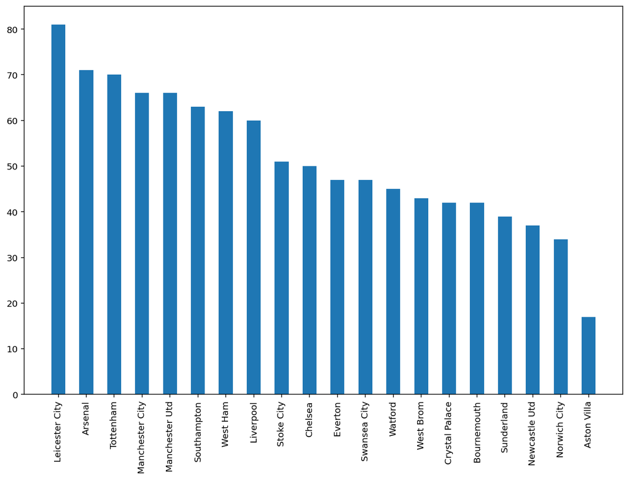

```python
plt.figure(figsize=(12,8))
plt.bar(league_table['Squad'][0:20],league_table['Pts'][0:20],width=0.5)
plt.xticks(rotation=90)#,ha='right')
# for i, v in enumerate(league_table['Pts'][0:2]):
#     plt.text(league_table['Pts'][i], v + 0.01, str(v) )
```

```python
t = pd.read_csv('match_results.csv')
t = t.drop(['Notes', 'Match Report'], axis=1)
# t['Wk'] = t['Wk'].astype(int)
print(t.dtypes)
t = t.dropna()
# t.loc[t['Wk'] == 1].size
# Make sure each week has 10 games
for i in range(1,39):
    if t.loc[t['Wk'] == i].size != 100:
        print(str(i) + " " + "False")
```

```
Wk            float64
Day            object
Date           object
Time           object
Home           object
Score          object
Away           object
Attendance    float64
Venue          object
Referee        object
dtype: object
```

just for fun, lets analyze the average home attendance, although each stadium is a different size:

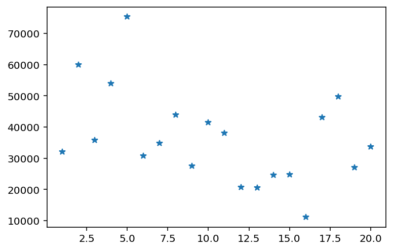

```python
plt.plot(league_table['Rk'], league_table['Attendance'], '*')
```

https://www.premierleague.com/history/origins#:~:text=In%20the%20early%201990s%2C%20English,up%20of%20the%20Premier%20League.  
https://en.wikipedia.org/wiki/Premier_League#Champions  
https://en.wikipedia.org/wiki/Leicester_City_F.C.  
https://pandas.pydata.org/docs/reference/index.html  
used https://rubular.com/ to configure regex  
https://fbref.com/en/comps/9/1467/2015-2016-Premier-League-Stats  
https://fbref.com/en/comps/9/1467/stats/2015-2016-Premier-League-Stats  
A huge thank you to Sports Reference (FBref) for providing free data. https://www.sports-reference.com/termsofuse.html, https://www.sports-reference.com/data_use.html